# Math 247: Homework 2

Warren Atkison

## Buttered toast

If you drop a piece of buttered toast on the floor, is it just as likely to land buttered side up as buttered side down? Suppose that 7 of the last 10 times I dropped toast it landed buttered side down. In order to carry out a statistical analysis, R was used to see whether my toast fell buttered side down a majority (more than 50%) of the time.

> 1. Use R to create a dotplot of of number of toasts that landed butter side down by chance alone. [Hint: Copy/Paste/Tweak the code from Explorations 1.1 and 1.2.].

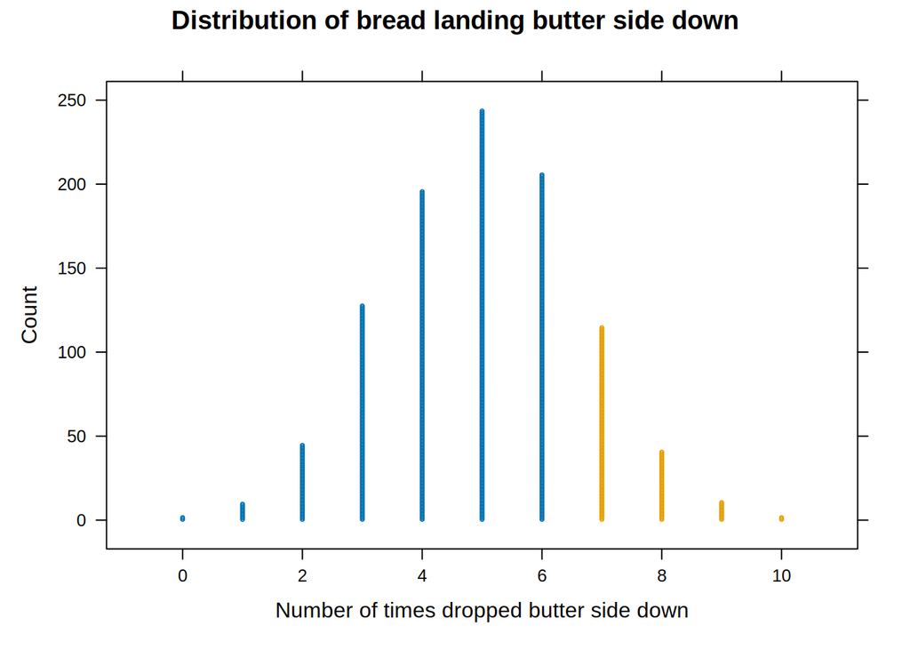

```r
set.seed(1000)
Bread.sims <- do(1000) * rflip(n = 10, prob = 0.5)
dotPlot(~heads, data = Bread.sims, width = 1, cex=3, groups = (prop >= 7/10),
xlab = "Number of times dropped butter side down",
main = "Distribution of bread landing butter side down")
```

```r
p.value <- prop(~(prop >= 7/10), data = Bread.sims)
p.value
```

```
## prop_TRUE
##     0.169
```

> 2. How many dots are in the dotplot?

1000

> 3. What does each dot represent in terms of dropped toast and buttered side down?

Number of times out of 10 toast was dropped butter side down if it was a 50/50 chance

> 4. At what number is the dotplot centered? Could you have determined that before running the simulation? Why or why not?

5/10. Yes, since that is the expected value if it were a 50/50 chance.

> 5. Based on 7 of the last 10 slices of toast landing buttered side down and the dotplot, are you convinced that the long-run proportion of times my toast lands buttered side down is greater than 0.50? Explain how you are deciding.

No, since 7/10 times or more wasn’t too unlikely, with a p-value of 0.169 which gives us no evidence against the null hypothesis

> 6. Does this prove that my long-run proportion of dropping toast buttered side down is 0.50?

No, but it gives no evidence against the null hypothesis.